# Prediction Assignment

**Executive Summary**

This assignment project will create a predictive model by training a dateset and running it against a testing set.

The training dataset is almost 20,000 observations of accelerometer measurements to evaluate the correctnesss of barbell lifts. A random forest model is created and is expected to predict the correctnesss of lifts.

**Load Training and Testing Files**

First, load the model libraries.

```r
library(caret)
library(randomForest)
```

Datasets are loaded with NAs inserted for empty values. Download links are in the Sources section at the end of the document.

```r
pml.training <- read.csv("~/Desktop/pml-training.csv", header=TRUE, na.strings = c("NA", ""))
pml.testing <- read.csv("~/Desktop/pml-testing.csv", header=TRUE, na.strings = c("NA", ""))
```

**Clean the Datasets**

The original training set has 160 variables.

```r
dim(pml.training)
```

```
## [1] 19622   160
```

```r
dim(pml.testing)
```

```
## [1]  20 160
```

Upon inspection of the training data with `View(training)`, many columns have significant NAs. For the model, these variables will be removed before building the model.

In addition, the first 7 columns contain variables not related to the prediction, such as timestamps and names.

```r
training <- pml.training[, -c(1:7)]
training <- training[, colSums(is.na(training)) == 0]
testing <- pml.testing[, -c(1:7)]
testing <- testing[, colSums(is.na(testing)) == 0]
```

This processing reduces the training set variables down from 160 to 53.

```r
dim(training)
```

```
## [1] 19622    53
```

**Partition Training Set for Validation**

Now, the training dataset will be partitioned at 70/30 to create a validation set. The `classe` variable contains the manner in which the exercise was conducted.

```r
inTrain <- createDataPartition(training$classe, p=0.7, list=FALSE)
subTrain <- training[inTrain,]
validTrain <- training[-inTrain,]
```

**Run Random Forest Model**

We will try to a random forest model. This should provide a good balance of accuracy to performance.

```r
model <- randomForest(classe ~., data=subTrain, importance=TRUE)
```

A quick plot of the the model will show the error rate over number of trees.

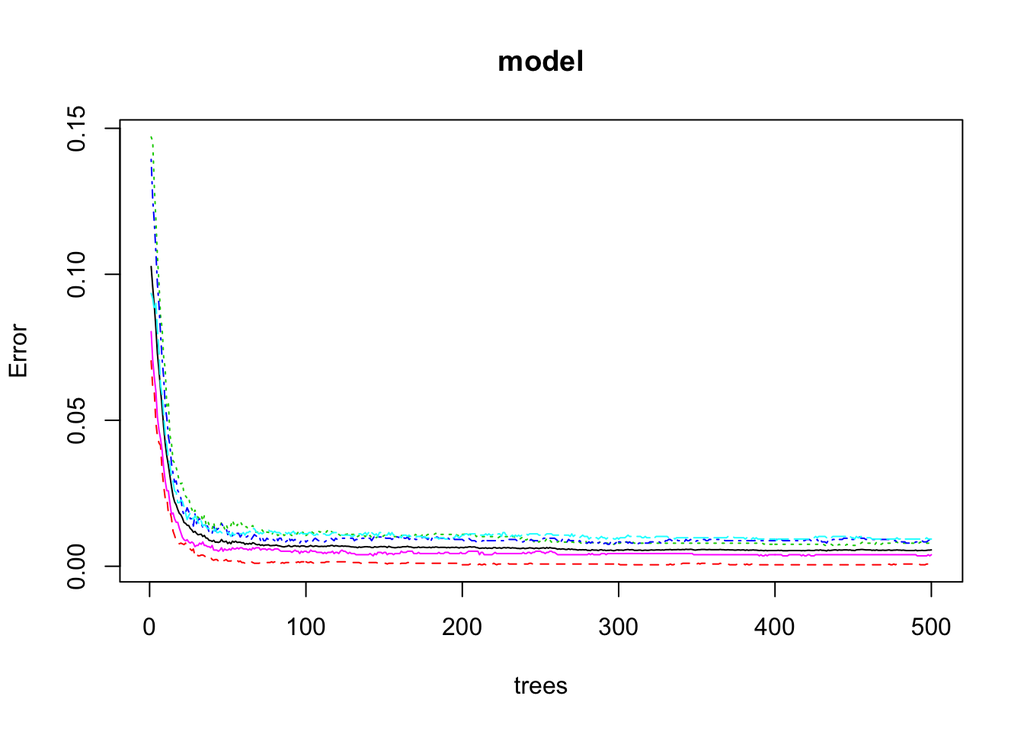

```r
plot(model)
```

**Run Model on Validation Set**

The model will now be run on our validation set and will generate a confusion matrix to check how well it perforrms on the validation partition.

```r
predictValid <- predict(model, newdata=validTrain)
confusionMatrix(predictValid, validTrain$classe)
```

```
## Confusion Matrix and Statistics
##
##           Reference
## Prediction    A    B    C    D    E
##          A 1674   13    0    0    0
##          B    0 1123   12    0    0
##          C    0    3 1013   16    0
##          D    0    0    1  947    4
##          E    0    0    0    1 1078
##
## Overall Statistics
##
##                Accuracy : 0.9915
##                  95% CI : (0.9888, 0.9937)
##     No Information Rate : 0.2845
##     P-Value [Acc > NIR] : < 2.2e-16
##
##                   Kappa : 0.9893
##  Mcnemar's Test P-Value : NA
##
## Statistics by Class:
##
##                      Class: A Class: B Class: C Class: D Class: E
## Sensitivity            1.0000   0.9860   0.9873   0.9824   0.9963
## Specificity            0.9969   0.9975   0.9961   0.9990   0.9998
## Pos Pred Value         0.9923   0.9894   0.9816   0.9947   0.9991
## Neg Pred Value         1.0000   0.9966   0.9973   0.9966   0.9992
## Prevalence             0.2845   0.1935   0.1743   0.1638   0.1839
## Detection Rate         0.2845   0.1908   0.1721   0.1609   0.1832
## Detection Prevalence   0.2867   0.1929   0.1754   0.1618   0.1833
## Balanced Accuracy      0.9985   0.9917   0.9917   0.9907   0.9980
```

Model accuracy is above 99%, so it is expected the out-of-sample error should be less than 1%.

**Prediction**

Now, we will create a vector of model outputs in order to predict the barbell correction on 20 observations from the `testing` dataset.

```r
answers <- predict(model, testing)
answers <- as.vector(answers)
answers
```

```
##  [1] "B" "A" "B" "A" "A" "E" "D" "B" "A" "A" "B" "C" "B" "A" "E" "E" "A"
## [18] "B" "B" "B"
```

The `answers` vector can now be submitted for grading.

**Sources**

Source for data comes from:

Ugulino, W.; Cardador, D.; Vega, K.; Velloso, E.; Milidiu, R.; Fuks, H. Wearable Computing: Accelerometers’ Data Classification of Body Postures and Movements. Proceedings of 21st Brazilian Symposium on Artificial Intelligence. Advances in Artificial Intelligence - SBIA 2012. In: Lecture Notes in Computer Science. , pp. 52-61. Curitiba, PR: Springer Berlin / Heidelberg, 2012. ISBN 978-3-642-34458-9. DOI: 10.1007/978-3-642-34459-6_6. http://groupware.les.inf.puc-rio.br/har

Data download links:

Training dataset https://d396qusza40orc.cloudfront.net/predmachlearn/pml-training.csv

Testing dataset https://d396qusza40orc.cloudfront.net/predmachlearn/pml-testing.csv